# Abas de Preços

Diego Oliveira Faria

11/25/2021

```r
knitr::opts_chunk$set(echo = TRUE)
library(PNADcIBGE)
library(survey)
library(srvyr)
library(tidyr)
library(dplyr)
library(kableExtra)
library(ggplot2)
rm(list = ls())
SM <- 998
```

## Objetivo

Atualizar aba de preços do modelo da previdência utilizando dados atualizados da PNAD.

As abas a serem atualizadas são:

- `SalMedSegUrbAcimH`: Atualização 1 vez no ano com base na PNAD
- `SalMedSegUrbAcimM`: Atualização 1 vez no ano com base na PNAD
- `SalMedPopOcupUrbH`: Atualizar 1 vez no ano com base na PNAD
- `SalMedPopOcupUrbM`: Atualizar 1 vez no ano com base na PNAD
- `SalMedPopOcupRurH`: Atualizar 1 vez no ano com base na PNAD
- `SalMedPopOcupRurM`: Atualizar 1 vez no ano com base na PNAD

## Carregamento dos Dados

As variáveis carregadas são:

```r
dados_srvyr<-as_survey(pnadc_design(read_pnadc("./data/PNADC_2019_visita5.txt","./data/input_PNADC_2019_visita5.txt",vars=c(
  'V1022',
  'V2005',
  'V4010',
  'V2009',
  'V2007',
  'VD4010',
  'VD4009',
  'VD4012',
  'VD4002',
  'VD4019'))))
```

## Filtros para classificação

### Classificação de Segurados Urbanos

De acordo com a Nota Técnica do IPEA e realizando algumas adptações necessárias devido às mudanças metodológicas da PNAD a partir de 2015, chegamos à seguinte classificação de segurados urbanos:

1. Empregados com carteira e empregados dom. com carteira em atividade nao agricola (VD4009 e VD4010);
2. Sem carteira/Contra Propria/Empregadores por CP/Em atividada nao agricola que contribuem para previdencia (VD4009 e VD4010);
3. Militares/Func Publicos Estatutarios no trabalho principal, independente do setor de trabalho.

```r
dados_srvyr <- dados_srvyr %>% mutate(Acima_SM = as.numeric(VD4019>SM))

dados_srvyr <- dados_srvyr %>% mutate(Seg_Urb =ifelse((V2009>=14&
                                                         (VD4009 %in% c('01','03')&VD4010!='01'|
                                                            VD4009 %in% c('02','04','06','08','09','10')&VD4010!='01'&VD4012=='1'|
                                                            VD4009 %in% c('05','07'))
                                                       ),1,0))
```

### Classificação de Ocupados Urbanos/Rurais

A nova metodologia da PNAD permite usar os mesmos indicadores da PNAD antiga para classificação quanto à ocupação.

- Os **ocupados urbanos** são aqueles cuja variável `VD4002` seja igual a 1 (ocupada), e a variável `VD4010` seja diferente de ‘01’ (Agricultura, pecuária, produção florestal, pesca e aquicultura).
- Os **ocupados rurais** são aqueles cuja variável `VD4002` seja igual a 1 (ocupada), e a variável `VD4010` seja igual a ‘01’ (Agricultura, pecuária, produção florestal, pesca e aquicultura).

```r
#Ocupado  Maior de 14 - Ocupado - Trabalha no Urbano

dados_srvyr <- dados_srvyr %>% mutate(Ocup_Urb =ifelse((V2009>=14&VD4002== '1'&VD4010 != '01'),1,0))


# Maior de 14 - Ocupado - Trabalha no Ramo Rural
dados_srvyr <- dados_srvyr %>% mutate(Ocup_Rur =ifelse((V2009>=14&VD4002=='1'&VD4010 == '01'),1,0))
```

## Renda Média - Segurados Urbanos Acima de 1 SM

```r
SalMedSegUrbAcimH<-dados_srvyr %>% mutate(V2009=as.factor(V2009)) %>% filter(Acima_SM==T,Seg_Urb==1,V2007=='1') %>% group_by(V2009) %>%
  summarise(SalMedSegUrbAcimH = survey_mean(VD4019,na.rm=T))

SalMedSegUrbAcimM<-dados_srvyr %>% mutate(V2009=as.factor(V2009)) %>% filter(Acima_SM==T,Seg_Urb==1,V2007=='2') %>% group_by(V2009) %>%
  summarise(SalMedSegUrbAcimM = survey_mean(VD4019,na.rm=T))
```

## Resultados

### Renda Média - Ocupados Urbanos e Rurais

```r
SalMedPopOcupUrbH<-dados_srvyr %>% mutate(V2009=as.factor(V2009)) %>% filter(Ocup_Urb==1,V2007=='1') %>% group_by(V2009) %>%
  summarise(SalMedPopOcupUrbH = survey_mean(VD4019,na.rm=T))

SalMedPopOcupUrbM<-dados_srvyr %>% mutate(V2009=as.factor(V2009)) %>% filter(Ocup_Urb==1,V2007=='2') %>% group_by(V2009) %>%
  summarise(SalMedPopOcupUrbM = survey_mean(VD4019,na.rm=T))

SalMedPopOcupRurH<- dados_srvyr %>% mutate(V2009=as.factor(V2009)) %>% filter(Ocup_Rur==1,V2007=='1') %>% group_by(V2009) %>%
  summarise(SalMedPopOcupRurH = survey_mean(VD4019,na.rm=T))

SalMedPopOcupRurM<- dados_srvyr %>% mutate(V2009=as.factor(V2009)) %>% filter(Ocup_Rur==1,V2007=='2') %>% group_by(V2009) %>%
  summarise(SalMedPopOcupRurM = survey_mean(VD4019,na.rm=T))
```

```r
arquivo_final <- dplyr::bind_cols(SalMedSegUrbAcimH,SalMedSegUrbAcimM[,2:3],SalMedPopOcupUrbH[,2:3],SalMedPopOcupUrbM[,2:3],SalMedPopOcupRurH[,2:3],SalMedPopOcupRurM[,2:3])

arquivo_final <- arquivo_final %>% mutate_if(is.numeric , replace_na, replace = 0)

arquivo_final<- arquivo_final %>% dplyr::rename('idade'='V2009')

arquivo_final %>% kbl() %>% kable_styling()
```

| idade | SalMedSegUrbAcimH | SalMedSegUrbAcimH_se | SalMedSegUrbAcimM | SalMedSegUrbAcimM_se | SalMedPopOcupUrbH | SalMedPopOcupUrbH_se | SalMedPopOcupUrbM | SalMedPopOcupUrbM_se | SalMedPopOcupRurH | SalMedPopOcupRurH_se | SalMedPopOcupRurM | SalMedPopOcupRurM_se |
| --- | --- | --- | --- | --- | --- | --- | --- | --- | --- | --- | --- | --- |
| 0 | 0.000 | 0.00000 | 0.000 | 0.00000 | 0.0000 | 0.00000 | 0.0000 | 0.00000 | 0.0000 | 0.00000 | 0.00000 | 0.000000 |
| 1 | 0.000 | 0.00000 | 0.000 | 0.00000 | 0.0000 | 0.00000 | 0.0000 | 0.00000 | 0.0000 | 0.00000 | 0.00000 | 0.000000 |
| 2 | 0.000 | 0.00000 | 0.000 | 0.00000 | 0.0000 | 0.00000 | 0.0000 | 0.00000 | 0.0000 | 0.00000 | 0.00000 | 0.000000 |
| 3 | 0.000 | 0.00000 | 0.000 | 0.00000 | 0.0000 | 0.00000 | 0.0000 | 0.00000 | 0.0000 | 0.00000 | 0.00000 | 0.000000 |
| 4 | 0.000 | 0.00000 | 0.000 | 0.00000 | 0.0000 | 0.00000 | 0.0000 | 0.00000 | 0.0000 | 0.00000 | 0.00000 | 0.000000 |
| 5 | 0.000 | 0.00000 | 0.000 | 0.00000 | 0.0000 | 0.00000 | 0.0000 | 0.00000 | 0.0000 | 0.00000 | 0.00000 | 0.000000 |
| 6 | 0.000 | 0.00000 | 0.000 | 0.00000 | 0.0000 | 0.00000 | 0.0000 | 0.00000 | 0.0000 | 0.00000 | 0.00000 | 0.000000 |
| 7 | 0.000 | 0.00000 | 0.000 | 0.00000 | 0.0000 | 0.00000 | 0.0000 | 0.00000 | 0.0000 | 0.00000 | 0.00000 | 0.000000 |
| 8 | 0.000 | 0.00000 | 0.000 | 0.00000 | 0.0000 | 0.00000 | 0.0000 | 0.00000 | 0.0000 | 0.00000 | 0.00000 | 0.000000 |
| 9 | 0.000 | 0.00000 | 0.000 | 0.00000 | 0.0000 | 0.00000 | 0.0000 | 0.00000 | 0.0000 | 0.00000 | 0.00000 | 0.000000 |
| 10 | 0.000 | 0.00000 | 0.000 | 0.00000 | 0.0000 | 0.00000 | 0.0000 | 0.00000 | 0.0000 | 0.00000 | 0.00000 | 0.000000 |
| 11 | 0.000 | 0.00000 | 0.000 | 0.00000 | 0.0000 | 0.00000 | 0.0000 | 0.00000 | 0.0000 | 0.00000 | 0.00000 | 0.000000 |
| 12 | 0.000 | 0.00000 | 0.000 | 0.00000 | 0.0000 | 0.00000 | 0.0000 | 0.00000 | 0.0000 | 0.00000 | 0.00000 | 0.000000 |
| 13 | 0.000 | 0.00000 | 0.000 | 0.00000 | 0.0000 | 0.00000 | 0.0000 | 0.00000 | 0.0000 | 0.00000 | 0.00000 | 0.000000 |
| 14 | 1000.000 | 0.00000 | 2500.000 | 0.00000 | 381.4322 | 43.91275 | 227.4204 | 36.45837 | 505.5607 | 132.89507 | 0.00000 | 0.000000 |
| 15 | 1400.000 | 0.00000 | 0.000 | 0.00000 | 444.4870 | 29.50077 | 381.9213 | 40.01659 | 337.9974 | 40.43771 | 833.00950 | 133.165913 |
| 16 | 1152.788 | 38.63865 | 1109.088 | 73.35174 | 524.8498 | 21.06631 | 518.4657 | 34.11426 | 525.9994 | 58.94640 | 259.57247 | 71.442042 |
| 17 | 1178.145 | 33.36185 | 1231.062 | 48.84732 | 649.2441 | 18.62629 | 627.1487 | 24.85485 | 661.7239 | 51.51513 | 615.44209 | 190.136833 |
| 18 | 1352.570 | 28.91812 | 1237.348 | 22.23982 | 930.5487 | 21.01575 | 780.3210 | 20.82395 | 761.3662 | 46.02488 | 773.63758 | 210.288827 |
| 19 | 1403.220 | 27.90667 | 1339.760 | 30.78274 | 1024.1578 | 18.63244 | 906.6550 | 24.71383 | 813.4539 | 49.74016 | 961.15238 | 102.201370 |
| 20 | 1542.137 | 54.74534 | 1317.020 | 20.58538 | 1163.5315 | 29.74360 | 990.3462 | 25.49485 | 888.2187 | 47.98014 | 965.97940 | 204.770586 |
| 21 | 1516.945 | 28.64645 | 1401.345 | 26.76210 | 1217.0613 | 21.63201 | 1045.1733 | 20.61858 | 887.3252 | 50.11843 | 1051.51825 | 95.766099 |
| 22 | 1691.756 | 39.05591 | 1528.097 | 36.15150 | 1322.1534 | 25.27976 | 1171.5588 | 26.01481 | 986.7047 | 52.43170 | 1081.18602 | 278.957484 |
| 23 | 1728.856 | 40.36830 | 1689.794 | 52.56608 | 1413.9398 | 27.63136 | 1255.6295 | 32.45126 | 971.2002 | 69.70379 | 1125.53807 | 254.601290 |
| 24 | 1867.341 | 43.96372 | 1738.180 | 38.56027 | 1528.9347 | 32.95092 | 1347.7612 | 28.18993 | 1006.5039 | 47.39895 | 1122.37476 | 212.523622 |
| 25 | 2014.976 | 51.33507 | 1832.916 | 76.78110 | 1644.2285 | 36.98789 | 1421.5006 | 46.56496 | 1028.8036 | 48.62123 | 1020.49564 | 169.107045 |
| 26 | 2208.068 | 56.81220 | 1979.381 | 60.00090 | 1762.4982 | 41.61523 | 1546.2225 | 41.39695 | 1017.5870 | 75.60765 | 1051.96477 | 181.246859 |
| 27 | 2332.727 | 78.71429 | 2102.563 | 116.51582 | 1928.6526 | 53.11674 | 1642.0315 | 70.07395 | 1101.8666 | 58.10730 | 890.21212 | 113.625305 |
| 28 | 2555.601 | 127.67797 | 2185.153 | 78.20790 | 2066.3695 | 84.32286 | 1734.6929 | 54.14527 | 1183.7341 | 97.95328 | 1385.36192 | 336.678991 |
| 29 | 2662.568 | 117.49873 | 2212.507 | 72.81301 | 2153.0032 | 79.30577 | 1695.9055 | 51.37824 | 1108.9904 | 98.93548 | 848.83459 | 138.035561 |

[output cut: 83 more lines]

### Arquivo Final

```r
openxlsx::write.xlsx(arquivo_final,'arquivo_final.xlsx',sheetName = "Preços")
```

## Análise Exploratória - Gênero

```r
require(stringr)

a_final_mulher_media <- arquivo_final %>% select(idade,SalMedPopOcupRurM) %>% pivot_longer(SalMedPopOcupRurM,names_to = 'Genero', values_to = "Media")%>% mutate(Genero = str_replace_all(Genero,'\\w+','M'))
a_final_mulher_media_se <- arquivo_final %>% select(idade,SalMedPopOcupRurM_se) %>% pivot_longer(SalMedPopOcupRurM_se,names_to = 'Genero', values_to = "SE") %>% mutate(Genero = str_replace_all(Genero,'\\w+','M'))
a_final_mulher<- a_final_mulher_media %>% left_join(a_final_mulher_media_se, by=c('idade','Genero'))


a_final_homem_media <- arquivo_final %>% select(idade,SalMedPopOcupRurH) %>% pivot_longer(SalMedPopOcupRurH,names_to = 'Genero', values_to = "Media")%>% mutate(Genero = str_replace_all(Genero,'\\w+','H'))
a_final_homem_media_se <- arquivo_final %>% select(idade,SalMedPopOcupRurH_se) %>% pivot_longer(SalMedPopOcupRurH_se,names_to = 'Genero', values_to = "SE") %>% mutate(Genero = str_replace_all(Genero,'\\w+','H'))
a_final_homem<- a_final_homem_media %>% left_join(a_final_homem_media_se, by=c('idade','Genero'))
df_ocup_Rur <- bind_rows(a_final_mulher,a_final_homem)


mulher_urb_media <- arquivo_final %>% select(idade,SalMedPopOcupUrbM) %>% pivot_longer(SalMedPopOcupUrbM,names_to = 'Genero', values_to = "Media")%>% mutate(Genero = str_replace_all(Genero,'\\w+','M'))
mulher_urb_se <- arquivo_final %>% select(idade,SalMedPopOcupUrbM_se) %>% pivot_longer(SalMedPopOcupUrbM_se,names_to = 'Genero', values_to = "SE") %>% mutate(Genero = str_replace_all(Genero,'\\w+','M'))
mulher_ocup_urb<- mulher_urb_media %>% left_join(mulher_urb_se, by=c('idade','Genero'))


homem_urb_media <- arquivo_final %>% select(idade,SalMedPopOcupUrbH) %>% pivot_longer(SalMedPopOcupUrbH,names_to = 'Genero', values_to = "Media")%>% mutate(Genero = str_replace_all(Genero,'\\w+','H'))
homem_urb_se <- arquivo_final %>% select(idade,SalMedPopOcupUrbH_se) %>% pivot_longer(SalMedPopOcupUrbH_se,names_to = 'Genero', values_to = "SE") %>% mutate(Genero = str_replace_all(Genero,'\\w+','H'))
homem_ocup_urb<- homem_urb_media %>% left_join(homem_urb_se, by=c('idade','Genero'))
df_ocup_Urb <- bind_rows(mulher_ocup_urb,homem_ocup_urb)


mulher_seg_media <- arquivo_final %>% select(idade,SalMedSegUrbAcimM) %>% pivot_longer(SalMedSegUrbAcimM,names_to = 'Genero', values_to = "Media")%>% mutate(Genero = str_replace_all(Genero,'\\w+','M'))
mulher_seg_se <- arquivo_final %>% select(idade,SalMedSegUrbAcimM_se) %>% pivot_longer(SalMedSegUrbAcimM_se,names_to = 'Genero', values_to = "SE") %>% mutate(Genero = str_replace_all(Genero,'\\w+','M'))
mulher_seg_urb<- mulher_seg_media %>% left_join(mulher_seg_se, by=c('idade','Genero'))


homem_seg_media <- arquivo_final %>% select(idade,SalMedSegUrbAcimH) %>% pivot_longer(SalMedSegUrbAcimH,names_to = 'Genero', values_to = "Media")%>% mutate(Genero = str_replace_all(Genero,'\\w+','H'))
homem_seg_se <- arquivo_final %>% select(idade,SalMedSegUrbAcimH_se) %>% pivot_longer(SalMedSegUrbAcimH_se,names_to = 'Genero', values_to = "SE") %>% mutate(Genero = str_replace_all(Genero,'\\w+','H'))
homem_seg_urb<- homem_seg_media %>% left_join(homem_seg_se, by=c('idade','Genero'))
df_seg_urb <- bind_rows(mulher_seg_urb,homem_seg_urb)
```

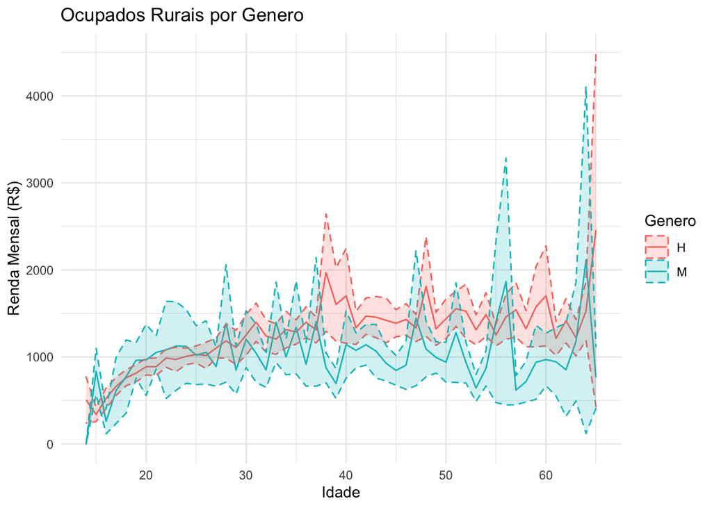

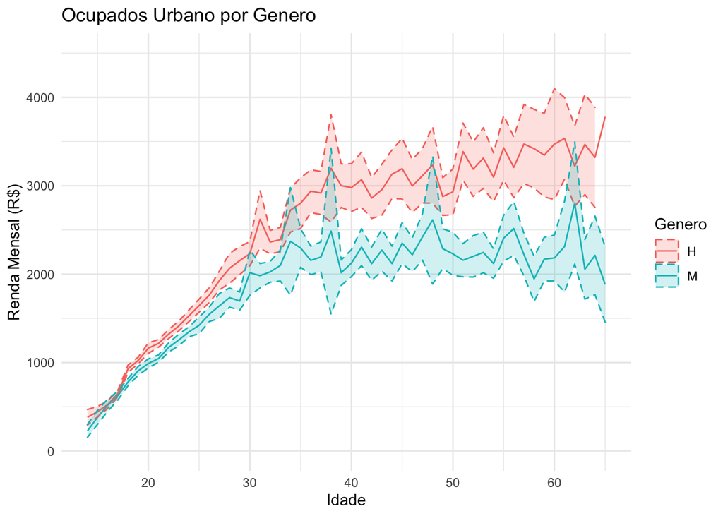

[figure not shown]